# anansi

Knowledge-based integration of multi-omics data: annotation-based analysis of specific interactions

Wednesday, September 30, 2026

## anansi

**Annotation-based Analysis of Specific Interactions**

- Integrates two omics data sets, e.g. **microbial functions** and **metabolites**
- Tests only the feature pairs that a **knowledge database** (e.g. KEGG) says can interact
- Tests whether associations **differ** between groups or along a covariate

Bastiaanssen, Quinn, and Cryan (2023) · R/Bioconductor package [anansi](https://thomazbastiaanssen.github.io/anansi/)

[figure not shown]

# Motivation

## The usual approach: all-vs-all correlation

Correlate every feature of data set $Y$ with every feature of data set $X$, then show a heatmap or a list of “significant” pairs.

Two problems:

1. **Hard to interpret**: results come without biological context; many significant pairs cannot be explained mechanistically
2. **Wastes statistical power**: every test adds a p-value to the multiple-testing correction (FDR), including tests of pairs that cannot biologically interact

Microbe–metabolite example: instead of correlating **taxa** with metabolites, correlate the **microbial genes (functions)** that make or use each metabolite. Then pathway knowledge tells us which pairs to test.

## Example: the Krebs cycle

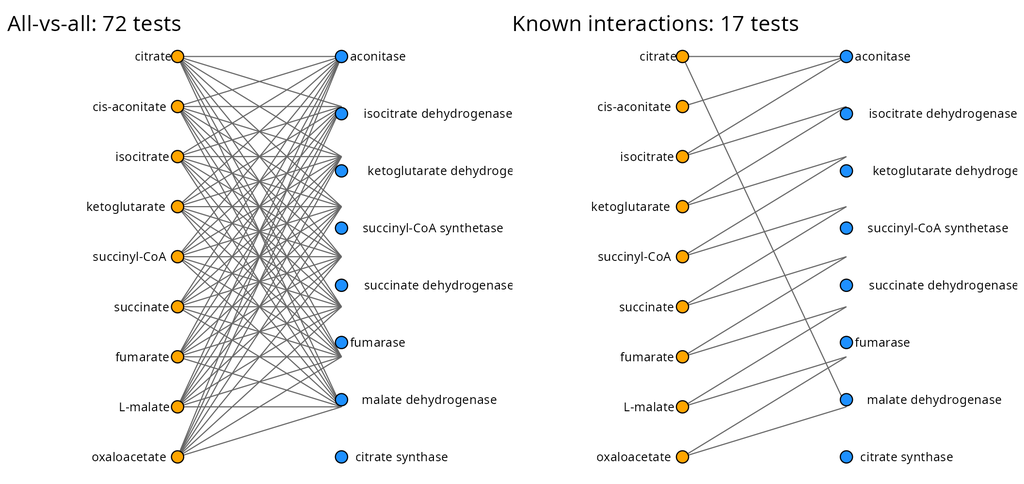

9 metabolites × 8 enzymes: of the 72 possible pairs, only 17 are known to interact. The other 55 tests cannot be interpreted, but still count in the FDR correction.

# The method

## Masking the association matrix

Two data sets on the same $N$ samples: $\mathbf{Y}$ ($M_Y$ features) and $\mathbf{X}$ ($M_X$ features).

**All-vs-all association matrix** ($M_Y \times M_X$):

$$\rho(\mathbf{Y}, \mathbf{X})_{ij} = \rho\big(f^{(Y)}_i, f^{(X)}_j\big)$$

**Binary (bi)adjacency matrix** from a knowledge database:

$$A_{ij} =
\begin{cases}
1 & \text{if features } i \text{ and } j \text{ are known to interact} \\
0 & \text{otherwise}
\end{cases}$$

**Masked association matrix**, the core output:

$$\mathbf{R} = \rho(\mathbf{Y}, \mathbf{X}) \circ \mathbf{A}$$

Masked pairs are never tested, so they don’t enter the FDR correction.

## Where does the adjacency matrix come from?

Knowledge databases list which features interact:

- **KEGG** (Kanehisa and Goto 2000): compounds (cpd), enzymes (EC numbers), orthologues (KO); shipped with anansi as `kegg_link()`
- Also MetaCyc, CAZy, HMDB, EggNOG, …; or any custom two-column table

```r
library(anansi)

lapply(kegg_link(), head, 3)
```

```
$ec2ko
       ec     ko
1 1.1.1.1 K00001
2 1.1.1.2 K00002
3 1.1.1.3 K00003

$ec2cpd
         ec    cpd
1   1.1.1.1 C00001
2 1.1.1.115 C00001
3 1.1.1.132 C00001
```

```r
# Biadjacency matrix linking KEGG compounds to KEGG orthologues
web_demo <- weaveWeb(cpd ~ ko, link = kegg_link())
dim(dictionary(web_demo))
```

```
[1] 6754 7270
```

## Beyond correlation: differential associations

Does the association between $y$ and $x$ **depend on a covariate**, such as treatment, disease status or a clinical score?

| Type | What changes | Tested as |
| --- | --- | --- |
| **Full** | total association of $y$ with $x$, incl. interactions | $y \sim x \times (\text{covariates})$ |
| **Disjointed** | the **slope** of the association | the $x{:}\text{covariate}$ interaction term |
| **Emergent** | the **strength** of the association (how tightly points follow the line) | how the spread around the line depends on the covariate |

- The paradigm comes from **differential proportionality** (Erb et al. 2017; Quinn et al. 2017), here applied outside the simplex
- Covariates can be **categorical or continuous**
- **Repeated measures**: random intercepts via `Error(subject)`, as in `stats::aov()`
- Each model reports $R^2$ or $\rho$, the test statistic, p-values and adjusted p-values

## Disjointed and emergent associations

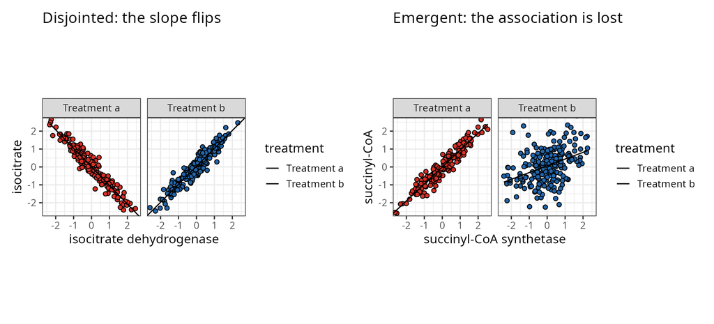

Simulated Krebs-cycle data with spiked-in effects (`krebsDemoWeb()`).

## The anansi workflow

1. **`weaveWeb()`**: combine the two feature tables, the linking information and the sample metadata into an `AnansiWeb` object; the features are matched through the biadjacency matrix
2. **`anansi()`**: fit the models for every linked feature pair; returns one row per pair with correlations, full, disjointed and emergent statistics, p-values and adjusted p-values
3. **`plotAnansi()`**, or your own ggplot2 code: visualize
- Input: plain tables, or **MultiAssayExperiment** / **TreeSummarizedExperiment**; `asMAE()` and `asTSE()` convert back
- `pairwiseApply()`: apply any function to every linked pair
- Linear models throughout, following `stats::lm()` / `aov()` conventions

# Example: FMT and ageing

## The study

Boehme et al. (2021): can faecal microbiota transplantation (FMT) from **young** donor mice reverse ageing-related changes in **aged** mice?

- Three groups: young mice given young FMT, aged mice given aged FMT, aged mice given young FMT
- Microbial functions (KEGG orthologues) inferred from 16S rRNA data
- Hippocampal metabolites
- An early version of anansi linked each metabolite to the microbial functions that produce or consume it

anansi ships curated subsets of these data as tutorial data:

```r
data(FMT_data)
dim(FMT_KOs)     # KOs x samples
```

```
[1] 6468   36
```

```r
dim(FMT_metab)   # metabolites x samples
```

```
[1]  3 36
```

```r
table(FMT_metadata$Legend)
```

```
 Aged oFMT  Aged yFMT Young yFMT
        12         12         12
```

## Weave the web

```r
web <- weaveWeb(
  cpd ~ ko,                  # link KEGG compounds (Y) to orthologues (X)
  link     = kegg_link(),
  tableY   = t(FMT_metab),   # samples as rows
  tableX   = t(FMT_KOs),
  metadata = FMT_metadata
)
web
```

```
anansi::AnansiWeb S7_object with 36 observations:
    tableY: cpd (3 features)
    tableX: ko (2476 features)
Use @ to access: tableX, tableY, dictionary, metadata.
```

## Run anansi

```r
out <- anansi(
  web,
  formula = ~ Legend,        # does the association depend on the group?
  adjust.method = "BH",
  verbose = FALSE
)

# All-vs-all would test every metabolite with every KO
c(all_vs_all = ncol(tableY(web)) * ncol(tableX(web)),
  tested     = nrow(out))    # one row per linked feature pair
```

```
all_vs_all     tested
      7428         65
```

```r
head(out[, 1:5], 4)
```

```
  feature_Y feature_X All_r.values All_t.values All_p.values
1    C00186    K00016  -0.08985529    0.5260699   0.60225456
2    C00186    K00101   0.28661046    1.7443940   0.09012569
3    C00041    K00259  -0.21708011    1.2967052   0.20346437
4    C00064    K00265  -0.25811198    1.5578255   0.12853530
```

## The output

```r
# Columns per model: statistic, test statistic, p-value, adjusted p-value
table(sub("_[^_]+$", "", colnames(out)[-(1:2)]))
```

```
        Aged oFMT         Aged yFMT               All disjointed_Legend
                4                 4                 4                 4
  emergent_Legend              full        Young yFMT
                4                 4                 4
```

| Association | Method | Statistics | Significance |
| --- | --- | --- | --- |
| Pooled (All) | correlation | $\rho$, $t$ | p, adjusted p |
| Per group | correlation | $\rho$, $t$ | p, adjusted p |
| Full | linear model | $R^2$, $F$ | p, adjusted p |
| Disjointed | linear model | $R^2$, $F$ | p, adjusted p |
| Emergent | linear model | $R^2$, $F$ | p, adjusted p |

## Visualize differential associations

```r
out_sig <- out[out$full_q.values < 0.2, ]   # pairs where the full model fits

plotAnansi(
  out_sig,
  association.type = "disjointed",
  model.var = "Legend",
  signif.threshold = 0.05,
  fill_by = "group"
)
```

## Visualize differential associations

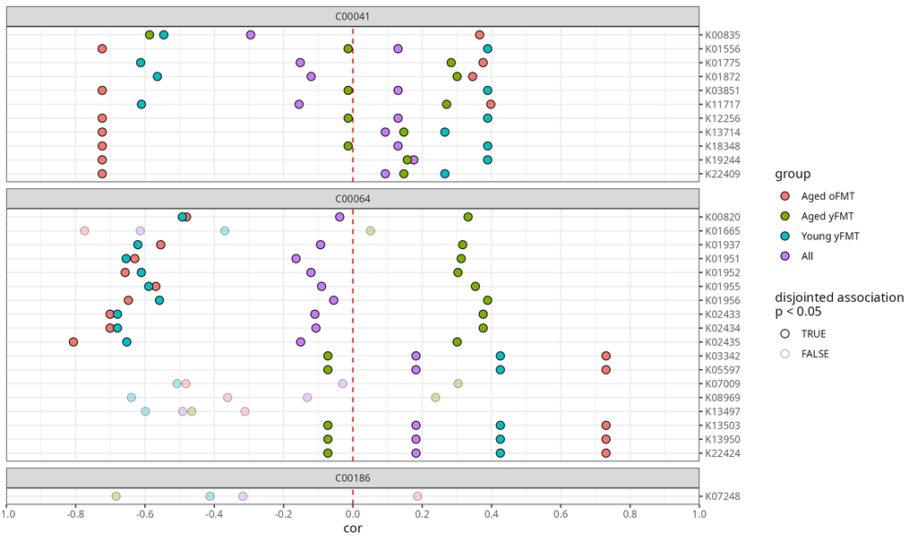

## Look at individual pairs

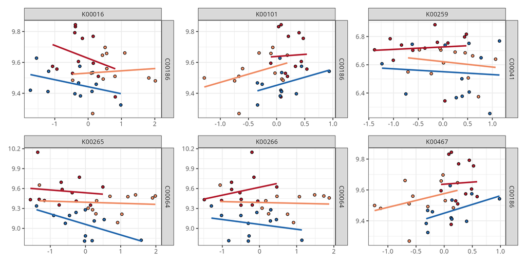

```r
pairs <- getFeaturePairs(web)
grp_cols <- c("Young yFMT" = "#2166ac", "Aged oFMT" = "#b2182b",
              "Aged yFMT" = "#ef8a62")

plots <- lapply(pairs[seq_len(6)], function(p) {
  ggplot(p, aes(y = .data[[colnames(p)[1]]], x = .data[[colnames(p)[2]]])) +
    facet_grid(colnames(p)[1] ~ colnames(p)[2])
})

wrap_plots(plots, ncol = 3) &
  geom_point(aes(fill = FMT_metadata$Legend), shape = 21,
             show.legend = FALSE) &
  geom_smooth(aes(colour = FMT_metadata$Legend), method = "lm",
              se = FALSE, show.legend = FALSE) &
  scale_fill_manual(values = grp_cols, aesthetics = c("colour", "fill")) &
  labs(x = NULL, y = NULL) &
  theme_bw(base_size = 12)
```

## More options

```r
# Continuous covariates and several terms
anansi(web, formula = ~ group + score, groups = "group")

# Repeated measures: random intercept per subject
anansi(web, formula = ~ group + Error(subject_id), groups = "group")

# Bioconductor containers in and out
mae <- asMAE(web)
web <- weaveWeb(mae, tableY = "cpd", tableX = "ko", link = kegg_link())

# Custom links: any two-column data.frame of feature IDs
web <- weaveWeb(y ~ x, link = my_links, tableY = tY, tableX = tX)

# Apply any function to each linked pair
pairwiseApply(web, FUN = function(x, y) cor(x, y, method = "spearman"))
```

## Related approaches

| Approach | Idea | Uses prior knowledge? |
| --- | --- | --- |
| All-vs-all correlation | every pair, then FDR | no |
| SparCC, SPIEC-EASI, proportionality | compositional association measures | no |
| HAllA | cluster features first, then test clusters | no (data-driven clusters) |
| DIABLO, MINT (mixOmics) | (sparse) PLS to discriminate phenotypes | no |
| mmvec | neural network for microbe–metabolite co-occurrence | no |
| **anansi** | test only **documented** feature pairs | **yes** |

anansi constrains the **hypothesis space** instead of letting the data decide which pairs to test.

## Limitations

- **Database coverage**: interactions that are real but not catalogued are never tested; many microbial metabolites and xenobiotics are still unmapped
- **Inferred functions are nested**: PICRUSt2 or HUMAnN function abundances depend on taxon abundances, so features are not independent; metatranscriptomics or metaproteomics would reduce this
- **Binary links**: interaction strength is a spectrum (e.g. binding affinities), but the adjacency matrix is 0/1
- Associations are **linear models**; compositional data should be transformed appropriately first

## Take-home messages

- anansi replaces **all-vs-all** testing with **knowledge-based** testing of feature pairs that are known to interact
- Results are **structured by pathways** and easier to interpret
- Fewer tests means **more power** after FDR correction
- **Differential associations**: disjointed (slope changes) and emergent (strength changes), with covariates and repeated measures
- Works with any pair of data sets that has a **dictionary**: metabolite–function, receptor–ligand, phage–bacterium, …
- R/Bioconductor, with **MultiAssayExperiment** and **TreeSummarizedExperiment** support

## References

Bastiaanssen, Thomaz F S, Thomas P Quinn, and John F Cryan. 2023. “Knowledge-Based Integration of Multi-Omic Datasets with Anansi: Annotation-Based Analysis of Specific Interactions.” *arXiv*. https://doi.org/10.48550/arXiv.2305.10832.

Boehme, Marcus, Katherine E. Guzzetta, Thomaz F. S. Bastiaanssen, Marcel van de Wouw, Gerard M. Moloney, others, and John F. Cryan. 2021. “Microbiota from Young Mice Counteracts Selective Age-Associated Behavioral Deficits.” *Nature Aging* 1 (8): 666–76. https://doi.org/10.1038/s43587-021-00093-9.

Erb, Ionas, Thomas Quinn, David Lovell, and Cedric Notredame. 2017. “Differential Proportionality – a Normalization-Free Approach to Differential Gene Expression.” *bioRxiv*. https://doi.org/10.1101/134536.

Kanehisa, Minoru, and Susumu Goto. 2000. “KEGG: Kyoto Encyclopedia of Genes and Genomes.” *Nucleic Acids Research* 28 (1): 27–30. https://doi.org/10.1093/nar/28.1.27.

Quinn, Thomas P., Mark F. Richardson, David Lovell, and Tamsyn M. Crowley. 2017. “propr: An R-Package for Identifying Proportionally Abundant Features Using Compositional Data Analysis.” *Scientific Reports* 7: 16252. https://doi.org/10.1038/s41598-017-16520-0.

Package and documentation: https://thomazbastiaanssen.github.io/anansi/